# Module 4: Expected Values Notes

## Expected Value

The expected value of a random variable $X$, $E(X)$, is a measure of its central tendency.

This is the center of a density or mass function (so it applies to both discrete and continuous random variables).

For discrete random variable $X$ with $PMF = p(x)$, it is defined as the sum of of all possible values of $x$ times the probability $p(x)$

$$E[X] = \sum\limits_x (x \times p(x))$$
For a coin flip, 0 = tails, 1 = heads:

$$E[X] = \sum\limits_x (x \times p(x)) = (0 \times \dfrac{1}{2}) + (1 \times \dfrac{1}{2}) = \dfrac{1}{2} = 0.5$$
For six sided die:

$$E[X] = \sum\limits_x (x \times p(x)) = (1 \times \dfrac{1}{6}) + (2 \times \dfrac{1}{6}) + (3 \times \dfrac{1}{6}) +
(4 \times \dfrac{1}{6}) + (5 \times \dfrac{1}{6}) + (6 \times \dfrac{1}{6}) = \dfrac {21}{6} = 3.5$$

## Summary

- **Expected Values** are properties of distributions
- **Population Mean** is the center of mass of a population
- **Sample Mean**
  - is the center of mass of the observed data
  - is an estimate of the **Population Mean**
  - is unbiased: the **Population Mean** of its distribution is the mean that it’s trying to estimate
- The more data that goes into a **Sample Mean**, the more concentrated its density/mass function is around the **Population Mean**

## Exercises

### Question 1

A standard die takes the values 1, 2, 3, 4, 5, 6 with equal probability. What is the expected value?

$$E[X] = \sum\limits_x (x \times p(x))
= (1 \times \dfrac{1}{6}) + (2 \times \dfrac{1}{6}) + (3 \times \dfrac{1}{6})
+ (4 \times \dfrac{1}{6}) + (5 \times \dfrac{1}{6}) + (6 \times \dfrac{1}{6})
= \dfrac {21}{6}
= \color{blue}{3.5}$$

### Question 2

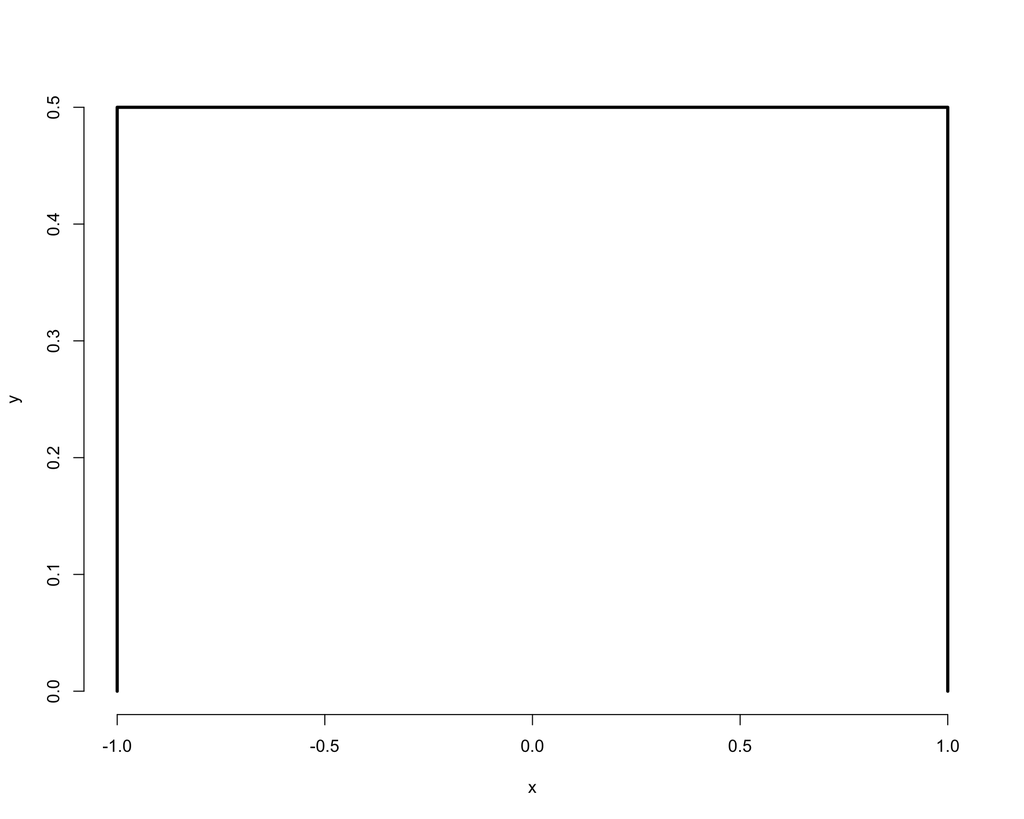

### Question 3

If a population has mean $μ$ , what is the mean of the distribution of averages of 20 observations from this distribution?

### Question 4

You are playing a game with a friend where you flip a coin and if it comes up heads you give her $X$ dollars and if it comes up tails she gives you $Y$ dollars. The odds that the coin is heads is $d$. What is your expected earnings?

### Question 5

If you roll ten standard dice, take their average, then repeat this process over and over and construct a histogram what would it be centered at?